# RPC-PI Experiment - Inference Time Analysis

2026-07-04

# 1 Objective

This R Markdown analyzes **inference cost**.

The main questions are:

```
How long does inference take for each scenario?
Does the defense add inference overhead?
Which split is more expensive?
How many examples per second does each scenario process?
How does inference cost relate to task utility and attack success?
```

This report uses:

```
logs/inference/05_run_inference_summary.json
logs/inference/05_run_inference_events.jsonl
logs/inference/runs/.../run_metadata.json
logs/inference/runs/.../test_*_metadata.json
```

It also optionally joins automatic metrics from:

```
tables/descriptive/01_inference_compact.csv
```

when that file exists.

# 2 Expected folder structure

This Rmd expects the logs extracted into one of these locations:

```
data/logs/inference/
logs/inference/
```

If `logs.zip` exists in the project root or inside `data/`, this Rmd tries to extract it automatically to `data/`.

# 3 Paths

```r
OUT_TABLE_DIR <- here::here("tables", "inference_time_analysis")
OUT_FIG_DIR <- here::here("figures", "inference_time_analysis")

fs::dir_create(OUT_TABLE_DIR)
fs::dir_create(OUT_FIG_DIR)

# Try to extract logs.zip automatically if needed.
if (!dir.exists(here::here("data", "logs")) && file.exists(here::here("logs.zip"))) {
  dir.create(here::here("data"), showWarnings = FALSE)
  unzip(here::here("logs.zip"), exdir = here::here("data"))
}

if (!dir.exists(here::here("data", "logs")) && file.exists(here::here("data", "logs.zip"))) {
  dir.create(here::here("data"), showWarnings = FALSE)
  unzip(here::here("data", "logs.zip"), exdir = here::here("data"))
}

candidate_inference_dirs <- c(
  here::here("data", "logs", "inference"),
  here::here("logs", "inference")
)

INFERENCE_LOG_DIR <- candidate_inference_dirs[dir.exists(candidate_inference_dirs)][1]

if (is.na(INFERENCE_LOG_DIR)) {
  stop(
    "Could not find inference logs. Expected one of:\n",
    paste(candidate_inference_dirs, collapse = "\n"),
    "\nOr place logs.zip in the project root or data/."
  )
}

SUMMARY_PATH <- file.path(INFERENCE_LOG_DIR, "05_run_inference_summary.json")
EVENTS_PATH <- file.path(INFERENCE_LOG_DIR, "05_run_inference_events.jsonl")
RUNS_DIR <- file.path(INFERENCE_LOG_DIR, "runs")
DESC_INFERENCE_PATH <- here::here("tables", "descriptive", "01_inference_compact.csv")

if (!file.exists(SUMMARY_PATH)) {
  stop("Could not find inference summary JSON: ", SUMMARY_PATH)
}
```

# 4 Helper functions

```r
`%||%` <- function(x, y) {
  if (is.null(x) || length(x) == 0) y else x
}

scenario_order <- c(
  "c0_base",
  "c1_struq_format_only",
  "c2_struq_sft",
  "c3_secalign_dpo",
  "c4_ih_sft"
)

scenario_labels <- tibble(
  scenario_id = scenario_order,
  scenario_short = c("C0", "C1", "C2", "C3", "C4"),
  scenario_label = c(
    "C0 - Base model",
    "C1 - StruQ format-only",
    "C2 - StruQ-like SFT",
    "C3 - SecAlign-like DPO",
    "C4 - Instruction-Hierarchy-like SFT"
  )
)

scenario_palette <- c(
  C0 = "#7F7F7F",
  C1 = "#D55E00",
  C2 = "#0072B2",
  C3 = "#CC79A7",
  C4 = "#009E73"
)

split_labels <- c(
  test_clean = "Clean",
  test_attacked_seen = "Attacked seen",
  test_attacked_unseen = "Attacked unseen",
  all_splits = "All splits",
  all_attacks = "All attacks"
)

split_order <- c(
  "test_clean",
  "test_attacked_seen",
  "test_attacked_unseen",
  "all_attacks",
  "all_splits"
)

sort_scenarios <- function(df) {
  df |>
    mutate(
      scenario_id = factor(as.character(scenario_id), levels = scenario_order),
      scenario_short = factor(as.character(scenario_short), levels = c("C0", "C1", "C2", "C3", "C4"))
    ) |>
    arrange(scenario_id)
}

add_scenario_info <- function(df) {
  out <- df |>
    mutate(scenario_id = as.character(scenario_id)) |>
    left_join(scenario_labels, by = "scenario_id", suffix = c("", "_lookup"))

  if (!("scenario_label" %in% names(out))) {
    out$scenario_label <- out$scenario_id
  }

  if ("scenario_label_lookup" %in% names(out)) {
    out <- out |>
      mutate(
        scenario_label = coalesce(
          as.character(scenario_label),
          as.character(scenario_label_lookup)
        )
      )
  }

  if (!("scenario_short" %in% names(out))) {
    out$scenario_short <- NA_character_
  }

  if ("scenario_short_lookup" %in% names(out)) {
    out <- out |>
      mutate(
        scenario_short = coalesce(
          as.character(scenario_short),
          as.character(scenario_short_lookup)
        )
      )
  }

  out |>
    mutate(
      scenario_short = ifelse(
        is.na(scenario_short),
        recode(
          as.character(scenario_id),
          c0_base = "C0",
          c1_struq_format_only = "C1",
          c2_struq_sft = "C2",
          c3_secalign_dpo = "C3",
          c4_ih_sft = "C4",
          .default = as.character(scenario_id)
        ),
        scenario_short
      )
    ) |>
    select(-any_of(c("scenario_label_lookup", "scenario_short_lookup"))) |>
    sort_scenarios()
}

get_scalar <- function(obj, field, default = NA) {
  value <- obj[[field]]

  if (is.null(value) || length(value) == 0) {
    return(default)
  }

  if (is.data.frame(value)) {
    if (nrow(value) == 0 || ncol(value) == 0) return(default)
    return(value[[1]][[1]])
  }

  if (is.list(value) && length(value) == 1 && !is.null(value[[1]])) {
    return(value[[1]])
  }

  value[[1]]
}

get_nested_scalar <- function(obj, parent, child, default = NA) {
  flat_name <- paste0(parent, ".", child)

  flat_value <- obj[[flat_name]]

  if (!is.null(flat_value) && length(flat_value) > 0) {
    return(flat_value[[1]])
  }

  parent_value <- obj[[parent]]

  if (!is.null(parent_value)) {
    if (is.data.frame(parent_value) && child %in% names(parent_value)) {
      return(parent_value[[child]][[1]])
    }

    if (is.list(parent_value) && !is.null(parent_value[[child]])) {
      return(parent_value[[child]][[1]])
    }
  }

  default
}

replace_null_columns <- function(x) {
  if (!is.list(x)) {
    return(x)
  }

  n <- 1
  non_null_lengths <- purrr::map_int(
    x,
    function(value) {
      if (is.null(value)) {
        0L
      } else if (is.data.frame(value)) {
        nrow(value)
      } else {
        length(value)
      }
    }
  )

  if (any(non_null_lengths > 0)) {
    n <- max(non_null_lengths)
  }

  purrr::map(
    x,
    function(value) {
      if (is.null(value)) {
        rep(NA_character_, n)
      } else {
        value
      }
    }
  )
}

as_tibble_json_safe <- function(x) {
  if (is.null(x)) {
    return(tibble())
  }

  if (is.data.frame(x)) {
    x <- replace_null_columns(x)
    return(tibble::as_tibble(x))
  }

  if (is.list(x)) {
    x <- replace_null_columns(x)
    return(tibble::as_tibble(x))
  }

  tibble(value = x)
}

parse_time_utc <- function(x) {
  lubridate::ymd_hms(x, tz = "UTC", quiet = TRUE)
}

safe_mean <- function(x) {
  if (sum(!is.na(x)) == 0) return(NA_real_)
  mean(x, na.rm = TRUE)
}

safe_weighted_mean <- function(x, w) {
  x <- as.numeric(x)
  w <- as.numeric(w)

  ok <- !is.na(x) & !is.na(w) & w > 0

  if (sum(ok) == 0) {
    return(NA_real_)
  }

  weighted.mean(x[ok], w = w[ok], na.rm = TRUE)
}

safe_sd <- function(x) {
  if (sum(!is.na(x)) <= 1) return(NA_real_)
  sd(x, na.rm = TRUE)
}

safe_sem <- function(x) {
  n <- sum(!is.na(x))
  if (n <= 1) return(NA_real_)
  sd(x, na.rm = TRUE) / sqrt(n)
}

safe_tcrit <- function(n, confidence = 0.95) {
  if (is.na(n) || n <= 1) return(NA_real_)
  alpha <- 1 - confidence
  qt(1 - alpha / 2, df = n - 1)
}

to_logical_safe <- function(x) {
  if (is.logical(x)) return(x)

  x_chr <- tolower(as.character(x))

  case_when(
    x_chr %in% c("true", "t", "1", "yes") ~ TRUE,
    x_chr %in% c("false", "f", "0", "no") ~ FALSE,
    TRUE ~ NA
  )
}

fmt_duration <- function(seconds) {
  ifelse(
    is.na(seconds),
    NA_character_,
    paste0(
      floor(seconds / 3600), "h ",
      floor((seconds %% 3600) / 60), "m ",
      round(seconds %% 60), "s"
    )
  )
}

fmt_number <- function(x, accuracy = 0.01) {
  scales::number(x, accuracy = accuracy, big.mark = ",")
}

fmt_pct <- function(x, accuracy = 0.1) {
  scales::percent(x, accuracy = accuracy)
}

base_theme <- function(base_size = 12) {
  theme_minimal(base_size = base_size) +
    theme(
      legend.position = "bottom",
      plot.title.position = "plot",
      plot.title = element_text(face = "bold"),
      plot.subtitle = element_text(color = "grey30"),
      panel.grid.minor = element_blank(),
      axis.title = element_text(face = "bold")
    )
}

write_inference_csv <- function(df, filename) {
  readr::write_csv(df, file.path(OUT_TABLE_DIR, filename))
  invisible(df)
}

save_inference_figure <- function(plot, filename, width = 10, height = 6) {
  ggsave(
    file.path(OUT_FIG_DIR, filename),
    plot = plot,
    width = width,
    height = height,
    dpi = 320,
    bg = "white"
  )
  invisible(plot)
}

read_jsonl_robust <- function(path, bad_lines_filename = "00_bad_jsonl_lines.csv") {
  if (!file.exists(path)) {
    return(tibble())
  }

  lines <- readLines(path, warn = FALSE, encoding = "UTF-8")

  if (length(lines) == 0) {
    return(tibble())
  }

  parsed <- vector("list", length(lines))
  bad_lines <- list()

  for (i in seq_along(lines)) {
    line <- lines[[i]]

    if (is.na(line) || trimws(line) == "") {
      next
    }

    obj <- tryCatch(
      jsonlite::fromJSON(line, flatten = TRUE),
      error = function(e) {
        bad_lines[[length(bad_lines) + 1]] <<- tibble(
          line_number = i,
          error = conditionMessage(e),
          line_prefix = substr(line, 1, 250)
        )
        NULL
      }
    )

    if (!is.null(obj)) {
      parsed[[i]] <- as_tibble_json_safe(obj)
    }
  }

  parsed <- parsed[!vapply(parsed, is.null, logical(1))]
  bad_lines_df <- dplyr::bind_rows(bad_lines)

  if (nrow(bad_lines_df) > 0) {
    readr::write_csv(
      bad_lines_df,
      file.path(OUT_TABLE_DIR, bad_lines_filename)
    )
  }

  if (length(parsed) == 0) {
    return(tibble())
  }

  dplyr::bind_rows(parsed)
}

read_split_metadata_file <- function(path) {
  obj <- jsonlite::fromJSON(path, flatten = TRUE)

  tibble(
    scenario_id = as.character(get_scalar(obj, "scenario_id", NA_character_)),
    scenario_label_raw = as.character(get_scalar(obj, "scenario_label", NA_character_)),
    seed = as.integer(get_scalar(obj, "seed", NA_integer_)),
    split = as.character(get_scalar(obj, "split", NA_character_)),
    status = as.character(get_scalar(obj, "status", NA_character_)),
    run_mode = as.character(get_scalar(obj, "run_mode", NA_character_)),
    started_at_utc = as.character(get_scalar(obj, "started_at_utc", NA_character_)),
    finished_at_utc = as.character(get_scalar(obj, "finished_at_utc", NA_character_)),
    elapsed_seconds = as.numeric(get_scalar(obj, "elapsed_seconds", NA_real_)),
    rows = as.numeric(get_scalar(obj, "rows", NA_real_)),
    output_path = as.character(get_scalar(obj, "output_path", NA_character_)),
    adapter_path = as.character(get_scalar(obj, "adapter_path", NA_character_)),
    prompt_strategy = as.character(get_scalar(obj, "prompt_strategy", NA_character_)),
    normalized_null_count = as.numeric(get_scalar(obj, "normalized_null_count", NA_real_)),
    max_new_tokens = as.numeric(get_nested_scalar(obj, "generation_config", "max_new_tokens", NA_real_)),
    do_sample = as.character(get_nested_scalar(obj, "generation_config", "do_sample", NA_character_)),
    num_beams = as.numeric(get_nested_scalar(obj, "generation_config", "num_beams", NA_real_)),
    metadata_path = as.character(path)
  )
}

read_run_metadata_file <- function(path) {
  obj <- jsonlite::fromJSON(path, flatten = TRUE)

  tibble(
    scenario_id = as.character(get_scalar(obj, "scenario_id", NA_character_)),
    scenario_label_raw = as.character(get_scalar(obj, "scenario_label", NA_character_)),
    seed = as.integer(get_scalar(obj, "seed", NA_integer_)),
    status = as.character(get_scalar(obj, "status", NA_character_)),
    run_mode = as.character(get_scalar(obj, "run_mode", NA_character_)),
    started_at_utc = as.character(get_scalar(obj, "started_at_utc", NA_character_)),
    finished_at_utc = as.character(get_scalar(obj, "finished_at_utc", NA_character_)),
    elapsed_seconds = as.numeric(get_scalar(obj, "elapsed_seconds", NA_real_)),
    adapter_path = as.character(get_scalar(obj, "adapter_path", NA_character_)),
    prompt_strategy = as.character(get_scalar(obj, "prompt_strategy", NA_character_)),
    metadata_path = as.character(path)
  )
}
```

# 5 Load inference summary

```r
inference_summary_json <- jsonlite::fromJSON(SUMMARY_PATH, flatten = TRUE)

generation_config <- inference_summary_json$generation_config %||% list()

experiment_metadata <- tibble(
  notebook = inference_summary_json$notebook %||% NA_character_,
  created_at_utc = inference_summary_json$created_at_utc %||% NA_character_,
  run_mode = inference_summary_json$run_mode %||% NA_character_,
  base_model_id = inference_summary_json$base_model_id %||% NA_character_,
  dataset_seed = inference_summary_json$dataset_seed %||% NA_integer_,
  max_input_length = inference_summary_json$max_input_length %||% NA_integer_,
  generation_batch_size = inference_summary_json$generation_batch_size %||% NA_integer_,
  use_4bit = inference_summary_json$use_4bit %||% NA,
  max_new_tokens = generation_config$max_new_tokens %||% NA_integer_,
  do_sample = generation_config$do_sample %||% NA,
  num_beams = generation_config$num_beams %||% NA_integer_,
  results_dir = inference_summary_json$results_dir %||% NA_character_,
  events_log_path = inference_summary_json$events_log_path %||% NA_character_,
  runs_log_dir = inference_summary_json$runs_log_dir %||% NA_character_
)

result_files <- as_tibble_json_safe(inference_summary_json$result_files) |>
  add_scenario_info() |>
  mutate(
    seed = as.integer(seed),
    split = as.character(split),
    rows = as.numeric(rows),
    exists = to_logical_safe(exists)
  ) |>
  sort_scenarios()

write_inference_csv(experiment_metadata, "01_inference_experiment_metadata.csv")
write_inference_csv(result_files, "02_inference_result_files_from_summary.csv")

experiment_metadata |>
  knitr::kable(
    caption = "Table 1 - Inference experiment metadata."
  )
```

Table 1 - Inference experiment metadata.

| notebook | created_at_utc | run_mode | base_model_id | dataset_seed | max_input_length | generation_batch_size | use_4bit | max_new_tokens | do_sample | num_beams | results_dir | events_log_path | runs_log_dir |
| --- | --- | --- | --- | --- | --- | --- | --- | --- | --- | --- | --- | --- | --- |
| 05_run_inference | 2026-06-29T23:30:18.907722+00:00 | full | meta-llama/Llama-3.1-8B-Instruct | 42 | 1536 | 4 | TRUE | 8 | FALSE | 1 | /workspace/pi-defense-exp/results/inference/full | /workspace/pi-defense-exp/logs/inference/05_run_inference_events.jsonl | /workspace/pi-defense-exp/logs/inference/runs |

```r
result_files |>
  select(scenario_short, seed, split, rows, exists, path) |>
  knitr::kable(
    caption = "Table 2 - Result files listed in inference summary."
  )
```

Table 2 - Result files listed in inference summary.

| scenario_short | seed | split | rows | exists | path |
| --- | --- | --- | --- | --- | --- |
| C0 | 42 | test_clean | 1876 | TRUE | /workspace/pi-defense-exp/results/inference/full/c0_base/seed_42/test_clean.jsonl |
| C0 | 42 | test_attacked_seen | 9380 | TRUE | /workspace/pi-defense-exp/results/inference/full/c0_base/seed_42/test_attacked_seen.jsonl |
| C0 | 42 | test_attacked_unseen | 5628 | TRUE | /workspace/pi-defense-exp/results/inference/full/c0_base/seed_42/test_attacked_unseen.jsonl |
| C1 | 42 | test_clean | 1876 | TRUE | /workspace/pi-defense-exp/results/inference/full/c1_struq_format_only/seed_42/test_clean.jsonl |
| C1 | 42 | test_attacked_seen | 9380 | TRUE | /workspace/pi-defense-exp/results/inference/full/c1_struq_format_only/seed_42/test_attacked_seen.jsonl |
| C1 | 42 | test_attacked_unseen | 5628 | TRUE | /workspace/pi-defense-exp/results/inference/full/c1_struq_format_only/seed_42/test_attacked_unseen.jsonl |
| C2 | 42 | test_clean | 1876 | TRUE | /workspace/pi-defense-exp/results/inference/full/c2_struq_sft/seed_42/test_clean.jsonl |
| C2 | 42 | test_attacked_seen | 9380 | TRUE | /workspace/pi-defense-exp/results/inference/full/c2_struq_sft/seed_42/test_attacked_seen.jsonl |
| C2 | 42 | test_attacked_unseen | 5628 | TRUE | /workspace/pi-defense-exp/results/inference/full/c2_struq_sft/seed_42/test_attacked_unseen.jsonl |
| C2 | 123 | test_clean | 1876 | TRUE | /workspace/pi-defense-exp/results/inference/full/c2_struq_sft/seed_123/test_clean.jsonl |
| C2 | 123 | test_attacked_seen | 9380 | TRUE | /workspace/pi-defense-exp/results/inference/full/c2_struq_sft/seed_123/test_attacked_seen.jsonl |
| C2 | 123 | test_attacked_unseen | 5628 | TRUE | /workspace/pi-defense-exp/results/inference/full/c2_struq_sft/seed_123/test_attacked_unseen.jsonl |
| C2 | 2026 | test_clean | 1876 | TRUE | /workspace/pi-defense-exp/results/inference/full/c2_struq_sft/seed_2026/test_clean.jsonl |
| C2 | 2026 | test_attacked_seen | 9380 | TRUE | /workspace/pi-defense-exp/results/inference/full/c2_struq_sft/seed_2026/test_attacked_seen.jsonl |
| C2 | 2026 | test_attacked_unseen | 5628 | TRUE | /workspace/pi-defense-exp/results/inference/full/c2_struq_sft/seed_2026/test_attacked_unseen.jsonl |
| C3 | 42 | test_clean | 1876 | TRUE | /workspace/pi-defense-exp/results/inference/full/c3_secalign_dpo/seed_42/test_clean.jsonl |
| C3 | 42 | test_attacked_seen | 9380 | TRUE | /workspace/pi-defense-exp/results/inference/full/c3_secalign_dpo/seed_42/test_attacked_seen.jsonl |
| C3 | 42 | test_attacked_unseen | 5628 | TRUE | /workspace/pi-defense-exp/results/inference/full/c3_secalign_dpo/seed_42/test_attacked_unseen.jsonl |
| C3 | 123 | test_clean | 1876 | TRUE | /workspace/pi-defense-exp/results/inference/full/c3_secalign_dpo/seed_123/test_clean.jsonl |
| C3 | 123 | test_attacked_seen | 9380 | TRUE | /workspace/pi-defense-exp/results/inference/full/c3_secalign_dpo/seed_123/test_attacked_seen.jsonl |
| C3 | 123 | test_attacked_unseen | 5628 | TRUE | /workspace/pi-defense-exp/results/inference/full/c3_secalign_dpo/seed_123/test_attacked_unseen.jsonl |
| C3 | 2026 | test_clean | 1876 | TRUE | /workspace/pi-defense-exp/results/inference/full/c3_secalign_dpo/seed_2026/test_clean.jsonl |
| C3 | 2026 | test_attacked_seen | 9380 | TRUE | /workspace/pi-defense-exp/results/inference/full/c3_secalign_dpo/seed_2026/test_attacked_seen.jsonl |
| C3 | 2026 | test_attacked_unseen | 5628 | TRUE | /workspace/pi-defense-exp/results/inference/full/c3_secalign_dpo/seed_2026/test_attacked_unseen.jsonl |
| C4 | 42 | test_clean | 1876 | TRUE | /workspace/pi-defense-exp/results/inference/full/c4_ih_sft/seed_42/test_clean.jsonl |
| C4 | 42 | test_attacked_seen | 9380 | TRUE | /workspace/pi-defense-exp/results/inference/full/c4_ih_sft/seed_42/test_attacked_seen.jsonl |
| C4 | 42 | test_attacked_unseen | 5628 | TRUE | /workspace/pi-defense-exp/results/inference/full/c4_ih_sft/seed_42/test_attacked_unseen.jsonl |
| C4 | 123 | test_clean | 1876 | TRUE | /workspace/pi-defense-exp/results/inference/full/c4_ih_sft/seed_123/test_clean.jsonl |
| C4 | 123 | test_attacked_seen | 9380 | TRUE | /workspace/pi-defense-exp/results/inference/full/c4_ih_sft/seed_123/test_attacked_seen.jsonl |
| C4 | 123 | test_attacked_unseen | 5628 | TRUE | /workspace/pi-defense-exp/results/inference/full/c4_ih_sft/seed_123/test_attacked_unseen.jsonl |
| C4 | 2026 | test_clean | 1876 | TRUE | /workspace/pi-defense-exp/results/inference/full/c4_ih_sft/seed_2026/test_clean.jsonl |
| C4 | 2026 | test_attacked_seen | 9380 | TRUE | /workspace/pi-defense-exp/results/inference/full/c4_ih_sft/seed_2026/test_attacked_seen.jsonl |
| C4 | 2026 | test_attacked_unseen | 5628 | TRUE | /workspace/pi-defense-exp/results/inference/full/c4_ih_sft/seed_2026/test_attacked_unseen.jsonl |

# 6 Load split metadata files

```r
split_metadata_files <- if (dir.exists(RUNS_DIR)) {
  fs::dir_ls(RUNS_DIR, recurse = TRUE, regexp = "test_.*_metadata\\.json$")
} else {
  character()
}

split_metadata <- purrr::map_dfr(
  split_metadata_files,
  read_split_metadata_file
) |>
  add_scenario_info() |>
  mutate(
    split = as.character(split),
    split_label = recode(split, !!!split_labels, .default = split),
    split_label = factor(split_label, levels = split_labels[c("test_clean", "test_attacked_seen", "test_attacked_unseen")]),
    started_at = parse_time_utc(started_at_utc),
    finished_at = parse_time_utc(finished_at_utc),
    elapsed_minutes = elapsed_seconds / 60,
    seconds_per_example = elapsed_seconds / rows,
    examples_per_second = rows / elapsed_seconds,
    generated_token_budget = rows * max_new_tokens,
    token_budget_per_second = generated_token_budget / elapsed_seconds,
    normalized_null_rate = normalized_null_count / rows,
    is_attacked_split = split %in% c("test_attacked_seen", "test_attacked_unseen"),
    adapter_used = !is.na(adapter_path) & adapter_path != "",
    prompt_strategy = ifelse(is.na(prompt_strategy) | prompt_strategy == "", "unknown", prompt_strategy)
  ) |>
  sort_scenarios()

if (nrow(split_metadata) == 0) {
  stop("No test_*_metadata.json files were found under: ", RUNS_DIR)
}

write_inference_csv(split_metadata, "03_inference_split_metadata_enriched.csv")

split_metadata |>
  select(
    scenario_short,
    seed,
    split,
    status,
    rows,
    elapsed_minutes,
    seconds_per_example,
    examples_per_second,
    normalized_null_count,
    normalized_null_rate,
    prompt_strategy,
    adapter_used
  ) |>
  mutate(
    elapsed_minutes = fmt_number(elapsed_minutes),
    seconds_per_example = fmt_number(seconds_per_example, accuracy = 0.0001),
    examples_per_second = fmt_number(examples_per_second, accuracy = 0.001),
    normalized_null_rate = fmt_pct(normalized_null_rate)
  ) |>
  knitr::kable(
    caption = "Table 3 - Inference split metadata."
  )
```

Table 3 - Inference split metadata.

| scenario_short | seed | split | status | rows | elapsed_minutes | seconds_per_example | examples_per_second | normalized_null_count | normalized_null_rate | prompt_strategy | adapter_used |
| --- | --- | --- | --- | --- | --- | --- | --- | --- | --- | --- | --- |
| C0 | 42 | test_attacked_seen | completed | 9380 | 5.32 | 0.0340 | 29.413 | 0 | 0.0% | plain | FALSE |
| C0 | 42 | test_attacked_unseen | completed | 5628 | 3.27 | 0.0349 | 28.682 | 1 | 0.0% | plain | FALSE |
| C0 | 42 | test_clean | completed | 1876 | 1.07 | 0.0342 | 29.244 | 5 | 0.3% | plain | FALSE |
| C1 | 42 | test_attacked_seen | completed | 9380 | 5.53 | 0.0354 | 28.276 | 4 | 0.0% | struq | FALSE |
| C1 | 42 | test_attacked_unseen | completed | 5628 | 3.41 | 0.0364 | 27.487 | 2 | 0.0% | struq | FALSE |
| C1 | 42 | test_clean | completed | 1876 | 1.12 | 0.0358 | 27.953 | 2 | 0.1% | struq | FALSE |
| C2 | 123 | test_attacked_seen | completed | 9380 | 7.58 | 0.0485 | 20.634 | 2 | 0.0% | struq | TRUE |
| C2 | 123 | test_attacked_unseen | completed | 5628 | 4.74 | 0.0505 | 19.783 | 0 | 0.0% | struq | TRUE |
| C2 | 123 | test_clean | completed | 1876 | 1.57 | 0.0501 | 19.976 | 0 | 0.0% | struq | TRUE |
| C2 | 2026 | test_attacked_seen | completed | 9380 | 7.52 | 0.0481 | 20.775 | 0 | 0.0% | struq | TRUE |
| C2 | 2026 | test_attacked_unseen | completed | 5628 | 4.70 | 0.0502 | 19.939 | 0 | 0.0% | struq | TRUE |
| C2 | 2026 | test_clean | completed | 1876 | 1.53 | 0.0490 | 20.409 | 0 | 0.0% | struq | TRUE |
| C2 | 42 | test_attacked_seen | completed | 9380 | 7.57 | 0.0484 | 20.650 | 0 | 0.0% | struq | TRUE |
| C2 | 42 | test_attacked_unseen | completed | 5628 | 4.73 | 0.0504 | 19.838 | 0 | 0.0% | struq | TRUE |
| C2 | 42 | test_clean | completed | 1876 | 1.56 | 0.0499 | 20.054 | 0 | 0.0% | struq | TRUE |
| C3 | 123 | test_attacked_seen | completed | 9380 | 9.10 | 0.0582 | 17.186 | 130 | 1.4% | secalign | TRUE |
| C3 | 123 | test_attacked_unseen | completed | 5628 | 5.03 | 0.0536 | 18.643 | 33 | 0.6% | secalign | TRUE |
| C3 | 123 | test_clean | completed | 1876 | 1.89 | 0.0605 | 16.536 | 7 | 0.4% | secalign | TRUE |
| C3 | 2026 | test_attacked_seen | completed | 9380 | 8.39 | 0.0536 | 18.644 | 45 | 0.5% | secalign | TRUE |
| C3 | 2026 | test_attacked_unseen | completed | 5628 | 4.93 | 0.0526 | 19.016 | 13 | 0.2% | secalign | TRUE |
| C3 | 2026 | test_clean | completed | 1876 | 1.59 | 0.0508 | 19.703 | 23 | 1.2% | secalign | TRUE |
| C3 | 42 | test_attacked_seen | completed | 9380 | 7.45 | 0.0477 | 20.982 | 2 | 0.0% | secalign | TRUE |
| C3 | 42 | test_attacked_unseen | completed | 5628 | 4.74 | 0.0506 | 19.778 | 0 | 0.0% | secalign | TRUE |
| C3 | 42 | test_clean | completed | 1876 | 1.57 | 0.0502 | 19.939 | 5 | 0.3% | secalign | TRUE |
| C4 | 123 | test_attacked_seen | completed | 9380 | 7.77 | 0.0497 | 20.129 | 0 | 0.0% | instruction_hierarchy | TRUE |
| C4 | 123 | test_attacked_unseen | completed | 5628 | 4.81 | 0.0513 | 19.490 | 0 | 0.0% | instruction_hierarchy | TRUE |
| C4 | 123 | test_clean | completed | 1876 | 1.59 | 0.0510 | 19.617 | 0 | 0.0% | instruction_hierarchy | TRUE |
| C4 | 2026 | test_attacked_seen | completed | 9380 | 7.80 | 0.0499 | 20.031 | 0 | 0.0% | instruction_hierarchy | TRUE |
| C4 | 2026 | test_attacked_unseen | completed | 5628 | 4.84 | 0.0516 | 19.379 | 0 | 0.0% | instruction_hierarchy | TRUE |
| C4 | 2026 | test_clean | completed | 1876 | 1.56 | 0.0498 | 20.063 | 0 | 0.0% | instruction_hierarchy | TRUE |
| C4 | 42 | test_attacked_seen | completed | 9380 | 7.75 | 0.0496 | 20.170 | 0 | 0.0% | instruction_hierarchy | TRUE |
| C4 | 42 | test_attacked_unseen | completed | 5628 | 4.81 | 0.0513 | 19.486 | 0 | 0.0% | instruction_hierarchy | TRUE |
| C4 | 42 | test_clean | completed | 1876 | 1.59 | 0.0507 | 19.715 | 0 | 0.0% | instruction_hierarchy | TRUE |

# 7 Load run metadata files

```r
run_metadata_files <- if (dir.exists(RUNS_DIR)) {
  fs::dir_ls(RUNS_DIR, recurse = TRUE, regexp = "run_metadata\\.json$")
} else {
  character()
}

run_metadata <- purrr::map_dfr(
  run_metadata_files,
  read_run_metadata_file
) |>
  add_scenario_info() |>
  mutate(
    started_at = parse_time_utc(started_at_utc),
    finished_at = parse_time_utc(finished_at_utc),
    elapsed_minutes = elapsed_seconds / 60,
    adapter_used = !is.na(adapter_path) & adapter_path != "",
    prompt_strategy = ifelse(is.na(prompt_strategy) | prompt_strategy == "", "unknown", prompt_strategy)
  ) |>
  left_join(
    split_metadata |>
      group_by(scenario_id, seed) |>
      summarise(
        split_elapsed_seconds_sum = sum(elapsed_seconds, na.rm = TRUE),
        split_rows_sum = sum(rows, na.rm = TRUE),
        split_count = n(),
        .groups = "drop"
      ),
    by = c("scenario_id", "seed")
  ) |>
  mutate(
    run_overhead_seconds = elapsed_seconds - split_elapsed_seconds_sum,
    run_overhead_rate = run_overhead_seconds / elapsed_seconds,
    run_examples_per_second = split_rows_sum / elapsed_seconds,
    run_seconds_per_example = elapsed_seconds / split_rows_sum
  ) |>
  sort_scenarios()

write_inference_csv(run_metadata, "04_inference_run_metadata_enriched.csv")

run_metadata |>
  select(
    scenario_short,
    seed,
    status,
    elapsed_minutes,
    split_elapsed_seconds_sum,
    run_overhead_seconds,
    run_overhead_rate,
    split_rows_sum,
    run_examples_per_second,
    run_seconds_per_example,
    prompt_strategy,
    adapter_used
  ) |>
  mutate(
    elapsed_minutes = fmt_number(elapsed_minutes),
    split_elapsed_seconds_sum = fmt_number(split_elapsed_seconds_sum),
    run_overhead_seconds = fmt_number(run_overhead_seconds),
    run_overhead_rate = fmt_pct(run_overhead_rate),
    run_examples_per_second = fmt_number(run_examples_per_second, accuracy = 0.001),
    run_seconds_per_example = fmt_number(run_seconds_per_example, accuracy = 0.0001)
  ) |>
  knitr::kable(
    caption = "Table 4 - Inference run-level metadata."
  )
```

Table 4 - Inference run-level metadata.

| scenario_short | seed | status | elapsed_minutes | split_elapsed_seconds_sum | run_overhead_seconds | run_overhead_rate | split_rows_sum | run_examples_per_second | run_seconds_per_example | prompt_strategy | adapter_used |
| --- | --- | --- | --- | --- | --- | --- | --- | --- | --- | --- | --- |
| C0 | 42 | completed | 9.73 | 579.27 | 4.59 | 0.8% | 16884 | 28.918 | 0.0346 | plain | FALSE |
| C1 | 42 | completed | 10.10 | 603.59 | 2.47 | 0.4% | 16884 | 27.859 | 0.0359 | struq | FALSE |
| C2 | 123 | completed | 13.97 | 832.99 | 5.49 | 0.7% | 16884 | 20.136 | 0.0497 | struq | TRUE |
| C2 | 2026 | completed | 13.86 | 825.67 | 5.63 | 0.7% | 16884 | 20.310 | 0.0492 | struq | TRUE |
| C2 | 42 | completed | 13.95 | 831.48 | 5.80 | 0.7% | 16884 | 20.165 | 0.0496 | struq | TRUE |
| C3 | 123 | completed | 16.11 | 961.14 | 5.39 | 0.6% | 16884 | 17.469 | 0.0572 | secalign | TRUE |
| C3 | 2026 | completed | 15.00 | 894.29 | 5.89 | 0.7% | 16884 | 18.756 | 0.0533 | secalign | TRUE |
| C3 | 42 | completed | 13.85 | 825.70 | 5.46 | 0.7% | 16884 | 20.314 | 0.0492 | secalign | TRUE |
| C4 | 123 | completed | 15.06 | 850.39 | 52.96 | 5.9% | 16884 | 18.691 | 0.0535 | instruction_hierarchy | TRUE |
| C4 | 2026 | completed | 14.30 | 852.18 | 5.58 | 0.7% | 16884 | 19.684 | 0.0508 | instruction_hierarchy | TRUE |
| C4 | 42 | completed | 14.24 | 849.04 | 5.64 | 0.7% | 16884 | 19.755 | 0.0506 | instruction_hierarchy | TRUE |

# 8 Split-level inference cost summary

```r
split_summary_by_scenario <- split_metadata |>
  group_by(
    scenario_id,
    scenario_short,
    scenario_label,
    split,
    split_label,
    prompt_strategy
  ) |>
  summarise(
    n_runs = n(),
    n_completed = sum(status == "completed", na.rm = TRUE),
    seeds = paste(sort(unique(seed)), collapse = ", "),
    rows_per_run = first(rows),
    total_rows = sum(rows, na.rm = TRUE),
    total_elapsed_seconds = sum(elapsed_seconds, na.rm = TRUE),
    mean_elapsed_seconds = mean(elapsed_seconds, na.rm = TRUE),
    sd_elapsed_seconds = safe_sd(elapsed_seconds),
    sem_elapsed_seconds = safe_sem(elapsed_seconds),
    tcrit_95 = safe_tcrit(n()),
    ci95_low_elapsed_seconds = mean_elapsed_seconds - tcrit_95 * sem_elapsed_seconds,
    ci95_high_elapsed_seconds = mean_elapsed_seconds + tcrit_95 * sem_elapsed_seconds,
    mean_seconds_per_example = mean(seconds_per_example, na.rm = TRUE),
    sd_seconds_per_example = safe_sd(seconds_per_example),
    mean_examples_per_second = mean(examples_per_second, na.rm = TRUE),
    sd_examples_per_second = safe_sd(examples_per_second),
    mean_token_budget_per_second = mean(token_budget_per_second, na.rm = TRUE),
    total_normalized_null_count = sum(normalized_null_count, na.rm = TRUE),
    normalized_null_rate = total_normalized_null_count / total_rows,
    .groups = "drop"
  ) |>
  mutate(
    mean_elapsed_minutes = mean_elapsed_seconds / 60,
    total_elapsed_minutes = total_elapsed_seconds / 60,
    ci95_low_elapsed_minutes = ci95_low_elapsed_seconds / 60,
    ci95_high_elapsed_minutes = ci95_high_elapsed_seconds / 60,
    mean_duration_label = fmt_duration(mean_elapsed_seconds),
    total_duration_label = fmt_duration(total_elapsed_seconds)
  ) |>
  sort_scenarios()

write_inference_csv(split_summary_by_scenario, "05_split_summary_by_scenario.csv")

split_summary_by_scenario |>
  select(
    scenario_short,
    split,
    prompt_strategy,
    n_runs,
    seeds,
    rows_per_run,
    mean_elapsed_minutes,
    mean_seconds_per_example,
    mean_examples_per_second,
    mean_token_budget_per_second,
    normalized_null_rate,
    mean_duration_label
  ) |>
  mutate(
    mean_elapsed_minutes = fmt_number(mean_elapsed_minutes),
    mean_seconds_per_example = fmt_number(mean_seconds_per_example, accuracy = 0.0001),
    mean_examples_per_second = fmt_number(mean_examples_per_second, accuracy = 0.001),
    mean_token_budget_per_second = fmt_number(mean_token_budget_per_second, accuracy = 0.001),
    normalized_null_rate = fmt_pct(normalized_null_rate)
  ) |>
  knitr::kable(
    caption = "Table 5 - Split-level inference cost by scenario."
  )
```

Table 5 - Split-level inference cost by scenario.

| scenario_short | split | prompt_strategy | n_runs | seeds | rows_per_run | mean_elapsed_minutes | mean_seconds_per_example | mean_examples_per_second | mean_token_budget_per_second | normalized_null_rate | mean_duration_label |
| --- | --- | --- | --- | --- | --- | --- | --- | --- | --- | --- | --- |
| C0 | test_attacked_seen | plain | 1 | 42 | 9380 | 5.32 | 0.0340 | 29.413 | 235.307 | 0.0% | 0h 5m 19s |
| C0 | test_attacked_unseen | plain | 1 | 42 | 5628 | 3.27 | 0.0349 | 28.682 | 229.458 | 0.0% | 0h 3m 16s |
| C0 | test_clean | plain | 1 | 42 | 1876 | 1.07 | 0.0342 | 29.244 | 233.953 | 0.3% | 0h 1m 4s |
| C1 | test_attacked_seen | struq | 1 | 42 | 9380 | 5.53 | 0.0354 | 28.276 | 226.209 | 0.0% | 0h 5m 32s |
| C1 | test_attacked_unseen | struq | 1 | 42 | 5628 | 3.41 | 0.0364 | 27.487 | 219.898 | 0.0% | 0h 3m 25s |
| C1 | test_clean | struq | 1 | 42 | 1876 | 1.12 | 0.0358 | 27.953 | 223.623 | 0.1% | 0h 1m 7s |
| C2 | test_attacked_seen | struq | 3 | 42, 123, 2026 | 9380 | 7.56 | 0.0483 | 20.686 | 165.491 | 0.0% | 0h 7m 33s |
| C2 | test_attacked_unseen | struq | 3 | 42, 123, 2026 | 5628 | 4.72 | 0.0504 | 19.853 | 158.827 | 0.0% | 0h 4m 43s |
| C2 | test_clean | struq | 3 | 42, 123, 2026 | 1876 | 1.55 | 0.0496 | 20.146 | 161.169 | 0.0% | 0h 1m 33s |
| C3 | test_attacked_seen | secalign | 3 | 42, 123, 2026 | 9380 | 8.31 | 0.0532 | 18.937 | 151.496 | 0.6% | 0h 8m 19s |
| C3 | test_attacked_unseen | secalign | 3 | 42, 123, 2026 | 5628 | 4.90 | 0.0523 | 19.146 | 153.166 | 0.3% | 0h 4m 54s |
| C3 | test_clean | secalign | 3 | 42, 123, 2026 | 1876 | 1.68 | 0.0538 | 18.726 | 149.807 | 0.6% | 0h 1m 41s |
| C4 | test_attacked_seen | instruction_hierarchy | 3 | 42, 123, 2026 | 9380 | 7.77 | 0.0497 | 20.110 | 160.880 | 0.0% | 0h 7m 46s |
| C4 | test_attacked_unseen | instruction_hierarchy | 3 | 42, 123, 2026 | 5628 | 4.82 | 0.0514 | 19.452 | 155.615 | 0.0% | 0h 4m 49s |
| C4 | test_clean | instruction_hierarchy | 3 | 42, 123, 2026 | 1876 | 1.58 | 0.0505 | 19.798 | 158.386 | 0.0% | 0h 1m 35s |

# 9 Scenario-level inference cost summary

```r
scenario_all_splits <- split_metadata |>
  group_by(
    scenario_id,
    scenario_short,
    scenario_label,
    seed,
    prompt_strategy
  ) |>
  summarise(
    split = "all_splits",
    split_label = "All splits",
    rows = sum(rows, na.rm = TRUE),
    elapsed_seconds = sum(elapsed_seconds, na.rm = TRUE),
    normalized_null_count = sum(normalized_null_count, na.rm = TRUE),
    .groups = "drop"
  ) |>
  mutate(
    seconds_per_example = elapsed_seconds / rows,
    examples_per_second = rows / elapsed_seconds,
    normalized_null_rate = normalized_null_count / rows
  )

scenario_all_attacks <- split_metadata |>
  filter(is_attacked_split) |>
  group_by(
    scenario_id,
    scenario_short,
    scenario_label,
    seed,
    prompt_strategy
  ) |>
  summarise(
    split = "all_attacks",
    split_label = "All attacks",
    rows = sum(rows, na.rm = TRUE),
    elapsed_seconds = sum(elapsed_seconds, na.rm = TRUE),
    normalized_null_count = sum(normalized_null_count, na.rm = TRUE),
    .groups = "drop"
  ) |>
  mutate(
    seconds_per_example = elapsed_seconds / rows,
    examples_per_second = rows / elapsed_seconds,
    normalized_null_rate = normalized_null_count / rows
  )

aggregate_split_metadata <- bind_rows(
  split_metadata |>
    select(
      scenario_id,
      scenario_short,
      scenario_label,
      seed,
      prompt_strategy,
      split,
      split_label,
      rows,
      elapsed_seconds,
      seconds_per_example,
      examples_per_second,
      normalized_null_count,
      normalized_null_rate
    ),
  scenario_all_attacks,
  scenario_all_splits
) |>
  mutate(
    split = factor(as.character(split), levels = split_order),
    split_label = factor(as.character(split_label), levels = split_labels[split_order])
  ) |>
  sort_scenarios()

scenario_inference_summary <- aggregate_split_metadata |>
  group_by(
    scenario_id,
    scenario_short,
    scenario_label,
    split,
    split_label,
    prompt_strategy
  ) |>
  summarise(
    n_runs = n(),
    seeds = paste(sort(unique(seed)), collapse = ", "),
    total_rows = sum(rows, na.rm = TRUE),
    mean_rows = mean(rows, na.rm = TRUE),
    total_elapsed_seconds = sum(elapsed_seconds, na.rm = TRUE),
    mean_elapsed_seconds = mean(elapsed_seconds, na.rm = TRUE),
    sd_elapsed_seconds = safe_sd(elapsed_seconds),
    mean_seconds_per_example = mean(seconds_per_example, na.rm = TRUE),
    sd_seconds_per_example = safe_sd(seconds_per_example),
    mean_examples_per_second = mean(examples_per_second, na.rm = TRUE),
    sd_examples_per_second = safe_sd(examples_per_second),
    total_normalized_null_count = sum(normalized_null_count, na.rm = TRUE),
    normalized_null_rate = total_normalized_null_count / total_rows,
    .groups = "drop"
  ) |>
  mutate(
    mean_elapsed_minutes = mean_elapsed_seconds / 60,
    total_elapsed_minutes = total_elapsed_seconds / 60,
    total_elapsed_hours = total_elapsed_seconds / 3600,
    mean_duration_label = fmt_duration(mean_elapsed_seconds),
    total_duration_label = fmt_duration(total_elapsed_seconds)
  ) |>
  sort_scenarios()

write_inference_csv(aggregate_split_metadata, "06_aggregate_split_metadata.csv")
write_inference_csv(scenario_inference_summary, "07_scenario_inference_summary.csv")

scenario_inference_summary |>
  filter(split %in% c("all_attacks", "all_splits")) |>
  select(
    scenario_short,
    split_label,
    prompt_strategy,
    n_runs,
    seeds,
    mean_rows,
    mean_elapsed_minutes,
    mean_seconds_per_example,
    mean_examples_per_second,
    normalized_null_rate,
    mean_duration_label
  ) |>
  mutate(
    mean_elapsed_minutes = fmt_number(mean_elapsed_minutes),
    mean_seconds_per_example = fmt_number(mean_seconds_per_example, accuracy = 0.0001),
    mean_examples_per_second = fmt_number(mean_examples_per_second, accuracy = 0.001),
    normalized_null_rate = fmt_pct(normalized_null_rate)
  ) |>
  knitr::kable(
    caption = "Table 6 - Scenario-level inference cost summary."
  )
```

Table 6 - Scenario-level inference cost summary.

| scenario_short | split_label | prompt_strategy | n_runs | seeds | mean_rows | mean_elapsed_minutes | mean_seconds_per_example | mean_examples_per_second | normalized_null_rate | mean_duration_label |
| --- | --- | --- | --- | --- | --- | --- | --- | --- | --- | --- |
| C0 | All attacks | plain | 1 | 42 | 15008 | 8.59 | 0.0343 | 29.135 | 0.0% | 0h 8m 35s |
| C0 | All splits | plain | 1 | 42 | 16884 | 9.65 | 0.0343 | 29.147 | 0.0% | 0h 9m 39s |
| C1 | All attacks | struq | 1 | 42 | 15008 | 8.94 | 0.0357 | 27.975 | 0.0% | 0h 8m 56s |
| C1 | All splits | struq | 1 | 42 | 16884 | 10.06 | 0.0357 | 27.973 | 0.0% | 0h 10m 4s |
| C2 | All attacks | struq | 3 | 42, 123, 2026 | 15008 | 12.28 | 0.0491 | 20.366 | 0.0% | 0h 12m 17s |
| C2 | All splits | struq | 3 | 42, 123, 2026 | 16884 | 13.83 | 0.0492 | 20.341 | 0.0% | 0h 13m 50s |
| C3 | All attacks | secalign | 3 | 42, 123, 2026 | 15008 | 13.21 | 0.0528 | 19.000 | 0.5% | 0h 13m 13s |
| C3 | All splits | secalign | 3 | 42, 123, 2026 | 16884 | 14.90 | 0.0529 | 18.965 | 0.5% | 0h 14m 54s |
| C4 | All attacks | instruction_hierarchy | 3 | 42, 123, 2026 | 15008 | 12.60 | 0.0504 | 19.858 | 0.0% | 0h 12m 36s |
| C4 | All splits | instruction_hierarchy | 3 | 42, 123, 2026 | 16884 | 14.18 | 0.0504 | 19.851 | 0.0% | 0h 14m 11s |

# 10 Inference overhead against C0

```r
c0_split_reference <- scenario_inference_summary |>
  filter(scenario_id == "c0_base") |>
  select(
    split,
    c0_mean_seconds_per_example = mean_seconds_per_example,
    c0_mean_examples_per_second = mean_examples_per_second,
    c0_mean_elapsed_seconds = mean_elapsed_seconds
  )

overhead_vs_c0 <- scenario_inference_summary |>
  left_join(c0_split_reference, by = "split") |>
  mutate(
    seconds_per_example_delta_vs_c0 = mean_seconds_per_example - c0_mean_seconds_per_example,
    relative_seconds_per_example_vs_c0 = mean_seconds_per_example / c0_mean_seconds_per_example,
    overhead_rate_vs_c0 = relative_seconds_per_example_vs_c0 - 1,
    examples_per_second_delta_vs_c0 = mean_examples_per_second - c0_mean_examples_per_second,
    relative_examples_per_second_vs_c0 = mean_examples_per_second / c0_mean_examples_per_second,
    elapsed_time_delta_vs_c0 = mean_elapsed_seconds - c0_mean_elapsed_seconds,
    relative_elapsed_time_vs_c0 = mean_elapsed_seconds / c0_mean_elapsed_seconds
  ) |>
  sort_scenarios()

write_inference_csv(overhead_vs_c0, "08_inference_overhead_vs_c0.csv")

overhead_vs_c0 |>
  filter(split %in% c("test_clean", "test_attacked_seen", "test_attacked_unseen", "all_splits")) |>
  select(
    scenario_short,
    split_label,
    mean_seconds_per_example,
    c0_mean_seconds_per_example,
    seconds_per_example_delta_vs_c0,
    relative_seconds_per_example_vs_c0,
    overhead_rate_vs_c0,
    mean_examples_per_second,
    relative_examples_per_second_vs_c0
  ) |>
  mutate(
    mean_seconds_per_example = fmt_number(mean_seconds_per_example, accuracy = 0.0001),
    c0_mean_seconds_per_example = fmt_number(c0_mean_seconds_per_example, accuracy = 0.0001),
    seconds_per_example_delta_vs_c0 = fmt_number(seconds_per_example_delta_vs_c0, accuracy = 0.0001),
    relative_seconds_per_example_vs_c0 = fmt_number(relative_seconds_per_example_vs_c0, accuracy = 0.001),
    overhead_rate_vs_c0 = fmt_pct(overhead_rate_vs_c0),
    mean_examples_per_second = fmt_number(mean_examples_per_second, accuracy = 0.001),
    relative_examples_per_second_vs_c0 = fmt_number(relative_examples_per_second_vs_c0, accuracy = 0.001)
  ) |>
  knitr::kable(
    caption = "Table 7 - Inference overhead against C0."
  )
```

Table 7 - Inference overhead against C0.

| scenario_short | split_label | mean_seconds_per_example | c0_mean_seconds_per_example | seconds_per_example_delta_vs_c0 | relative_seconds_per_example_vs_c0 | overhead_rate_vs_c0 | mean_examples_per_second | relative_examples_per_second_vs_c0 |
| --- | --- | --- | --- | --- | --- | --- | --- | --- |
| C0 | Clean | 0.0342 | 0.0342 | 0.0000 | 1.000 | 0.0% | 29.244 | 1.000 |
| C0 | Attacked seen | 0.0340 | 0.0340 | 0.0000 | 1.000 | 0.0% | 29.413 | 1.000 |
| C0 | Attacked unseen | 0.0349 | 0.0349 | 0.0000 | 1.000 | 0.0% | 28.682 | 1.000 |
| C0 | All splits | 0.0343 | 0.0343 | 0.0000 | 1.000 | 0.0% | 29.147 | 1.000 |
| C1 | Clean | 0.0358 | 0.0342 | 0.0016 | 1.046 | 4.6% | 27.953 | 0.956 |
| C1 | Attacked seen | 0.0354 | 0.0340 | 0.0014 | 1.040 | 4.0% | 28.276 | 0.961 |
| C1 | Attacked unseen | 0.0364 | 0.0349 | 0.0015 | 1.043 | 4.3% | 27.487 | 0.958 |
| C1 | All splits | 0.0357 | 0.0343 | 0.0014 | 1.042 | 4.2% | 27.973 | 0.960 |
| C2 | Clean | 0.0496 | 0.0342 | 0.0154 | 1.452 | 45.2% | 20.146 | 0.689 |
| C2 | Attacked seen | 0.0483 | 0.0340 | 0.0143 | 1.422 | 42.2% | 20.686 | 0.703 |
| C2 | Attacked unseen | 0.0504 | 0.0349 | 0.0155 | 1.445 | 44.5% | 19.853 | 0.692 |
| C2 | All splits | 0.0492 | 0.0343 | 0.0149 | 1.433 | 43.3% | 20.341 | 0.698 |
| C3 | Clean | 0.0538 | 0.0342 | 0.0196 | 1.573 | 57.3% | 18.726 | 0.640 |
| C3 | Attacked seen | 0.0532 | 0.0340 | 0.0192 | 1.564 | 56.4% | 18.937 | 0.644 |
| C3 | Attacked unseen | 0.0523 | 0.0349 | 0.0174 | 1.499 | 49.9% | 19.146 | 0.668 |
| C3 | All splits | 0.0529 | 0.0343 | 0.0186 | 1.543 | 54.3% | 18.965 | 0.651 |
| C4 | Clean | 0.0505 | 0.0342 | 0.0163 | 1.477 | 47.7% | 19.798 | 0.677 |
| C4 | Attacked seen | 0.0497 | 0.0340 | 0.0157 | 1.463 | 46.3% | 20.110 | 0.684 |
| C4 | Attacked unseen | 0.0514 | 0.0349 | 0.0165 | 1.475 | 47.5% | 19.452 | 0.678 |
| C4 | All splits | 0.0504 | 0.0343 | 0.0161 | 1.468 | 46.8% | 19.851 | 0.681 |

# 11 Prompt strategy and adapter overhead

```r
prompt_strategy_summary <- aggregate_split_metadata |>
  group_by(prompt_strategy, split, split_label) |>
  summarise(
    n_runs = n(),
    scenarios = paste(sort(unique(as.character(scenario_short))), collapse = ", "),
    total_rows = sum(rows, na.rm = TRUE),
    total_elapsed_seconds = sum(elapsed_seconds, na.rm = TRUE),
    mean_seconds_per_example = mean(seconds_per_example, na.rm = TRUE),
    mean_examples_per_second = mean(examples_per_second, na.rm = TRUE),
    normalized_null_rate = sum(normalized_null_count, na.rm = TRUE) / total_rows,
    .groups = "drop"
  ) |>
  mutate(
    total_elapsed_minutes = total_elapsed_seconds / 60
  )

write_inference_csv(prompt_strategy_summary, "09_prompt_strategy_inference_summary.csv")

prompt_strategy_summary |>
  filter(split %in% c("test_clean", "all_attacks", "all_splits")) |>
  select(
    prompt_strategy,
    split_label,
    scenarios,
    n_runs,
    total_rows,
    total_elapsed_minutes,
    mean_seconds_per_example,
    mean_examples_per_second,
    normalized_null_rate
  ) |>
  mutate(
    total_elapsed_minutes = fmt_number(total_elapsed_minutes),
    mean_seconds_per_example = fmt_number(mean_seconds_per_example, accuracy = 0.0001),
    mean_examples_per_second = fmt_number(mean_examples_per_second, accuracy = 0.001),
    normalized_null_rate = fmt_pct(normalized_null_rate)
  ) |>
  knitr::kable(
    caption = "Table 8 - Prompt strategy inference summary."
  )
```

Table 8 - Prompt strategy inference summary.

| prompt_strategy | split_label | scenarios | n_runs | total_rows | total_elapsed_minutes | mean_seconds_per_example | mean_examples_per_second | normalized_null_rate |
| --- | --- | --- | --- | --- | --- | --- | --- | --- |
| instruction_hierarchy | Clean | C4 | 3 | 5628 | 4.74 | 0.0505 | 19.798 | 0.0% |
| instruction_hierarchy | All attacks | C4 | 3 | 45024 | 37.79 | 0.0504 | 19.858 | 0.0% |
| instruction_hierarchy | All splits | C4 | 3 | 50652 | 42.53 | 0.0504 | 19.851 | 0.0% |
| plain | Clean | C0 | 1 | 1876 | 1.07 | 0.0342 | 29.244 | 0.3% |
| plain | All attacks | C0 | 1 | 15008 | 8.59 | 0.0343 | 29.135 | 0.0% |
| plain | All splits | C0 | 1 | 16884 | 9.65 | 0.0343 | 29.147 | 0.0% |
| secalign | Clean | C3 | 3 | 5628 | 5.05 | 0.0538 | 18.726 | 0.6% |
| secalign | All attacks | C3 | 3 | 45024 | 39.64 | 0.0528 | 19.000 | 0.5% |
| secalign | All splits | C3 | 3 | 50652 | 44.69 | 0.0529 | 18.965 | 0.5% |
| struq | Clean | C1, C2 | 4 | 7504 | 5.77 | 0.0462 | 22.098 | 0.0% |
| struq | All attacks | C1, C2 | 4 | 60032 | 45.79 | 0.0458 | 22.268 | 0.0% |
| struq | All splits | C1, C2 | 4 | 67536 | 51.56 | 0.0458 | 22.249 | 0.0% |

# 12 Events and errors

```r
inference_events <- read_jsonl_robust(
  EVENTS_PATH,
  bad_lines_filename = "00_bad_inference_event_lines.csv"
)

if (nrow(inference_events) > 0) {
  if (!("scenario_id" %in% names(inference_events)) && "scenario" %in% names(inference_events)) {
    inference_events <- inference_events |>
      rename(scenario_id = scenario)
  }

  inference_events <- inference_events |>
    add_scenario_info() |>
    mutate(
      seed = as.integer(seed),
      event_type = as.character(event_type),
      run_mode = as.character(run_mode),
      split = if ("split" %in% names(inference_events)) as.character(split) else NA_character_,
      timestamp = parse_time_utc(timestamp_utc),
      rows = if ("rows" %in% names(inference_events)) as.numeric(rows) else NA_real_,
      elapsed_seconds = if ("elapsed_seconds" %in% names(inference_events)) as.numeric(elapsed_seconds) else NA_real_,
      normalized_null_count = if ("normalized_null_count" %in% names(inference_events)) as.numeric(normalized_null_count) else NA_real_,
      examples_per_second = rows / elapsed_seconds,
      seconds_per_example = elapsed_seconds / rows
    ) |>
    sort_scenarios()

  event_counts <- inference_events |>
    count(run_mode, scenario_id, scenario_short, seed, event_type, name = "n_events") |>
    sort_scenarios()

  split_completion_events <- inference_events |>
    filter(event_type == "split_completed") |>
    mutate(
      normalized_null_rate = normalized_null_count / rows
    ) |>
    select(
      run_mode,
      scenario_id,
      scenario_short,
      seed,
      split,
      rows,
      elapsed_seconds,
      examples_per_second,
      seconds_per_example,
      normalized_null_count,
      normalized_null_rate,
      timestamp
    ) |>
    sort_scenarios()

  write_inference_csv(inference_events, "10_inference_events_enriched.csv")
  write_inference_csv(event_counts, "11_inference_event_counts.csv")
  write_inference_csv(split_completion_events, "12_split_completion_events.csv")

  event_counts |>
    knitr::kable(
      caption = "Table 9 - Inference event counts."
    )
} else {
  cat("No inference events found.")
}
```

Table 9 - Inference event counts.

| run_mode | scenario_id | scenario_short | seed | event_type | n_events |
| --- | --- | --- | --- | --- | --- |
| full | c0_base | C0 | 42 | run_completed | 1 |
| full | c0_base | C0 | 42 | run_failed | 1 |
| full | c0_base | C0 | 42 | run_started | 2 |
| full | c0_base | C0 | 42 | split_completed | 3 |
| full | c0_base | C0 | 42 | split_started | 3 |
| smoke | c0_base | C0 | 42 | run_completed | 1 |
| smoke | c0_base | C0 | 42 | run_started | 1 |
| smoke | c0_base | C0 | 42 | split_completed | 3 |
| smoke | c0_base | C0 | 42 | split_started | 3 |
| full | c1_struq_format_only | C1 | 42 | run_completed | 1 |
| full | c1_struq_format_only | C1 | 42 | run_started | 1 |
| full | c1_struq_format_only | C1 | 42 | split_completed | 3 |
| full | c1_struq_format_only | C1 | 42 | split_started | 3 |
| smoke | c1_struq_format_only | C1 | 42 | run_completed | 1 |
| smoke | c1_struq_format_only | C1 | 42 | run_started | 1 |
| smoke | c1_struq_format_only | C1 | 42 | split_completed | 3 |
| smoke | c1_struq_format_only | C1 | 42 | split_started | 3 |
| full | c2_struq_sft | C2 | 42 | run_completed | 1 |
| full | c2_struq_sft | C2 | 42 | run_started | 1 |
| full | c2_struq_sft | C2 | 42 | split_completed | 3 |
| full | c2_struq_sft | C2 | 42 | split_started | 3 |
| full | c2_struq_sft | C2 | 123 | run_completed | 1 |
| full | c2_struq_sft | C2 | 123 | run_started | 1 |
| full | c2_struq_sft | C2 | 123 | split_completed | 3 |
| full | c2_struq_sft | C2 | 123 | split_started | 3 |
| full | c2_struq_sft | C2 | 2026 | run_completed | 1 |
| full | c2_struq_sft | C2 | 2026 | run_started | 1 |
| full | c2_struq_sft | C2 | 2026 | split_completed | 3 |
| full | c2_struq_sft | C2 | 2026 | split_started | 3 |
| smoke | c2_struq_sft | C2 | 42 | run_completed | 1 |

[output cut: 59 more lines]

```r
error_files <- if (dir.exists(RUNS_DIR)) {
  fs::dir_ls(RUNS_DIR, recurse = TRUE, regexp = "error\\.txt$")
} else {
  character()
}

inference_errors <- purrr::map_dfr(
  error_files,
  function(path) {
    parts <- stringr::str_split(as.character(path), "[/\\\\]", simplify = TRUE)
    runs_idx <- which(parts == "runs")

    scenario <- if (length(runs_idx) > 0) parts[runs_idx + 1] else NA_character_
    seed_part <- if (length(runs_idx) > 0) parts[runs_idx + 2] else NA_character_
    seed <- stringr::str_remove(seed_part, "^seed_")

    error_text <- paste(readLines(path, warn = FALSE, encoding = "UTF-8"), collapse = "\n")

    tibble(
      scenario_id = scenario,
      seed = as.integer(seed),
      error_path = as.character(path),
      error_text = error_text,
      error_preview = substr(error_text, 1, 500)
    )
  }
)

if (nrow(inference_errors) > 0) {
  inference_errors <- inference_errors |>
    add_scenario_info() |>
    sort_scenarios()

  write_inference_csv(inference_errors, "13_inference_error_files.csv")

  inference_errors |>
    select(scenario_short, seed, error_path, error_preview) |>
    knitr::kable(
      caption = "Table 10 - Error files found in inference run directories."
    )
} else {
  cat("No error.txt files found in inference run directories.")
}
```

Table 10 - Error files found in inference run directories.

| scenario_short | seed | error_path | error_preview |
| --- | --- | --- | --- |
| C0 | 42 | D:/LETICIA/UFCG/RPC/RPC-PI-EXPERIMENT/pi-defense-analysis/data/logs/inference/runs/c0_base/seed_42/error.txt | Traceback (most recent call last): |

File “/tmp/ipykernel_14328/2391120856.py”, line 36, in model = load_model_for_inference(adapter_path=adapter_path) ^ File “/tmp/ipykernel_14328/3663304092.py”, line 23, in load_model_for_inference dtype=_dtype, NameError: name ’_dtype’ is not defined. Did you mean: ‘dtype’? |

# 13 Optional join with quality metrics

```r
if (file.exists(DESC_INFERENCE_PATH)) {
  inference_compact <- readr::read_csv(DESC_INFERENCE_PATH, show_col_types = FALSE) |>
    add_scenario_info()

  if (!("is_correct_flag" %in% names(inference_compact))) {
    if (all(c("normalized_output", "expected_answer") %in% names(inference_compact))) {
      inference_compact$is_correct_flag <- inference_compact$normalized_output == inference_compact$expected_answer
    } else {
      inference_compact$is_correct_flag <- NA
    }
  }

  if (!("followed_attack_flag" %in% names(inference_compact))) {
    if (all(c("normalized_output", "attack_target") %in% names(inference_compact))) {
      inference_compact$followed_attack_flag <- inference_compact$normalized_output == inference_compact$attack_target
    } else {
      inference_compact$followed_attack_flag <- NA
    }
  }

  if (!("invalid_output_flag" %in% names(inference_compact))) {
    inference_compact$invalid_output_flag <- NA
  }

  quality_by_split <- inference_compact |>
    mutate(
      seed = as.integer(seed),
      split = as.character(eval_split),
      is_correct_flag = to_logical_safe(is_correct_flag),
      followed_attack_flag = to_logical_safe(followed_attack_flag),
      invalid_output_flag = to_logical_safe(invalid_output_flag),
      is_attacked_split = split %in% c("test_attacked_seen", "test_attacked_unseen")
    ) |>
    group_by(scenario_id, scenario_short, scenario_label, seed, split) |>
    summarise(
      metric_rows = n(),
      accuracy = mean(as.integer(is_correct_flag), na.rm = TRUE),
      asv_rate = if_else(
        first(is_attacked_split),
        mean(as.integer(followed_attack_flag), na.rm = TRUE),
        NA_real_
      ),
      invalid_output_rate = mean(as.integer(invalid_output_flag), na.rm = TRUE),
      .groups = "drop"
    ) |>
    sort_scenarios()

  quality_all_attacks <- quality_by_split |>
    filter(split %in% c("test_attacked_seen", "test_attacked_unseen")) |>
    group_by(scenario_id, scenario_short, scenario_label, seed) |>
    summarise(
      split = "all_attacks",
      accuracy = safe_weighted_mean(accuracy, metric_rows),
      asv_rate = safe_weighted_mean(asv_rate, metric_rows),
      invalid_output_rate = safe_weighted_mean(invalid_output_rate, metric_rows),
      metric_rows = sum(metric_rows, na.rm = TRUE),
      .groups = "drop"
    )

  quality_all_splits <- quality_by_split |>
    group_by(scenario_id, scenario_short, scenario_label, seed) |>
    summarise(
      split = "all_splits",
      accuracy = safe_weighted_mean(accuracy, metric_rows),
      asv_rate = safe_weighted_mean(asv_rate, metric_rows),
      invalid_output_rate = safe_weighted_mean(invalid_output_rate, metric_rows),
      metric_rows = sum(metric_rows, na.rm = TRUE),
      .groups = "drop"
    )

  quality_metrics_full <- bind_rows(
    quality_by_split,
    quality_all_attacks,
    quality_all_splits
  )

  inference_cost_quality <- aggregate_split_metadata |>
    left_join(
      quality_metrics_full |>
        select(
          scenario_id,
          seed,
          split,
          metric_rows,
          accuracy,
          asv_rate,
          invalid_output_rate
        ),
      by = c("scenario_id", "seed", "split")
    ) |>
    mutate(
      correct_examples_per_second = accuracy * examples_per_second,
      attack_successes_per_second = asv_rate * examples_per_second,
      robust_accuracy_per_second = if_else(
        split %in% c("test_attacked_seen", "test_attacked_unseen", "all_attacks"),
        accuracy / seconds_per_example,
        NA_real_
      ),
      asv_reduction_proxy_per_second = if_else(
        split %in% c("test_attacked_seen", "test_attacked_unseen", "all_attacks"),
        (1 - asv_rate) / seconds_per_example,
        NA_real_
      )
    ) |>
    sort_scenarios()

  write_inference_csv(quality_by_split, "14_quality_metrics_by_split.csv")
  write_inference_csv(inference_cost_quality, "15_inference_cost_quality_joined.csv")

  inference_cost_quality |>
    filter(split %in% c("test_clean", "all_attacks")) |>
    select(
      scenario_short,
      seed,
      split,
      seconds_per_example,
      examples_per_second,
      accuracy,
      asv_rate,
      invalid_output_rate,
      correct_examples_per_second,
      robust_accuracy_per_second,
      asv_reduction_proxy_per_second
    ) |>
    mutate(
      seconds_per_example = fmt_number(seconds_per_example, accuracy = 0.0001),
      examples_per_second = fmt_number(examples_per_second, accuracy = 0.001),
      accuracy = fmt_pct(accuracy),
      asv_rate = fmt_pct(asv_rate),
      invalid_output_rate = fmt_pct(invalid_output_rate),
      correct_examples_per_second = fmt_number(correct_examples_per_second, accuracy = 0.001),
      robust_accuracy_per_second = fmt_number(robust_accuracy_per_second, accuracy = 0.001),
      asv_reduction_proxy_per_second = fmt_number(asv_reduction_proxy_per_second, accuracy = 0.001)
    ) |>
    knitr::kable(
      caption = "Table 11 - Inference cost joined with task and attack metrics."
    )
} else {
  inference_cost_quality <- NULL
  cat("tables/descriptive/01_inference_compact.csv not found. Quality-cost join skipped.")
}
```

Table 11 - Inference cost joined with task and attack metrics.

| scenario_short | seed | split | seconds_per_example | examples_per_second | accuracy | asv_rate | invalid_output_rate | correct_examples_per_second | robust_accuracy_per_second | asv_reduction_proxy_per_second |
| --- | --- | --- | --- | --- | --- | --- | --- | --- | --- | --- |
| C0 | 42 | test_clean | 0.0342 | 29.244 | 77.3% | - | 0.3% | 22.603 | - | - |
| C0 | 42 | all_attacks | 0.0343 | 29.135 | 21.3% | 78.2% | 0.0% | 6.202 | 6.202 | 6.356 |
| C1 | 42 | test_clean | 0.0358 | 27.953 | 77.3% | - | 0.1% | 21.620 | - | - |
| C1 | 42 | all_attacks | 0.0357 | 27.975 | 21.0% | 78.5% | 0.0% | 5.868 | 5.868 | 6.010 |
| C2 | 123 | test_clean | 0.0501 | 19.976 | 85.6% | - | 0.0% | 17.090 | - | - |
| C2 | 2026 | test_clean | 0.0490 | 20.409 | 85.6% | - | 0.0% | 17.471 | - | - |
| C2 | 42 | test_clean | 0.0499 | 20.054 | 85.9% | - | 0.0% | 17.232 | - | - |
| C2 | 42 | all_attacks | 0.0492 | 20.338 | 98.5% | 0.3% | 0.0% | 20.037 | 20.037 | 20.284 |
| C2 | 123 | all_attacks | 0.0492 | 20.306 | 98.3% | 0.5% | 0.0% | 19.952 | 19.952 | 20.198 |
| C2 | 2026 | all_attacks | 0.0489 | 20.454 | 98.3% | 0.5% | 0.0% | 20.113 | 20.113 | 20.353 |
| C3 | 123 | test_clean | 0.0605 | 16.536 | 72.8% | - | 0.4% | 12.041 | - | - |
| C3 | 2026 | test_clean | 0.0508 | 19.703 | 77.8% | - | 1.2% | 15.334 | - | - |
| C3 | 42 | test_clean | 0.0502 | 19.939 | 74.6% | - | 0.3% | 14.879 | - | - |
| C3 | 42 | all_attacks | 0.0487 | 20.514 | 95.5% | 2.9% | 0.0% | 19.599 | 19.599 | 19.918 |
| C3 | 123 | all_attacks | 0.0565 | 17.705 | 96.6% | 0.9% | 1.1% | 17.096 | 17.096 | 17.551 |
| C3 | 2026 | all_attacks | 0.0532 | 18.782 | 81.8% | 16.6% | 0.4% | 15.366 | 15.366 | 15.667 |
| C4 | 123 | test_clean | 0.0510 | 19.617 | 86.1% | - | 0.0% | 16.888 | - | - |
| C4 | 2026 | test_clean | 0.0498 | 20.063 | 85.0% | - | 0.0% | 17.058 | - | - |
| C4 | 42 | test_clean | 0.0507 | 19.715 | 85.8% | - | 0.0% | 16.919 | - | - |
| C4 | 42 | all_attacks | 0.0502 | 19.908 | 98.6% | 0.0% | 0.0% | 19.630 | 19.630 | 19.900 |
| C4 | 123 | all_attacks | 0.0503 | 19.885 | 98.6% | 0.0% | 0.0% | 19.608 | 19.608 | 19.881 |
| C4 | 2026 | all_attacks | 0.0506 | 19.782 | 98.6% | 0.1% | 0.0% | 19.502 | 19.502 | 19.766 |

# 14 Figures

## 14.1 Split elapsed time by scenario

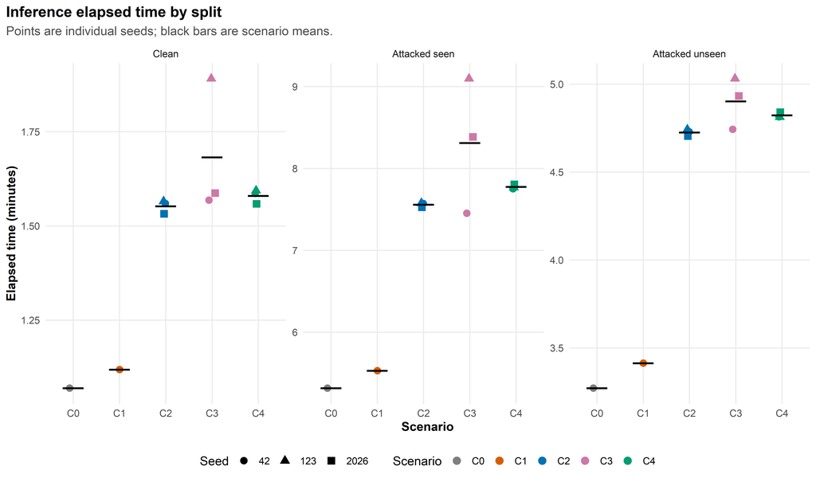

```r
p_split_elapsed <- split_metadata |>
  ggplot(aes(x = scenario_short, y = elapsed_minutes, color = scenario_short)) +
  geom_point(aes(shape = factor(seed)), size = 3.1, position = position_jitter(width = 0.08, height = 0)) +
  stat_summary(
    fun = mean,
    geom = "crossbar",
    width = 0.45,
    color = "black",
    linewidth = 0.35
  ) +
  facet_wrap(~ split_label, scales = "free_y") +
  scale_color_manual(values = scenario_palette, drop = FALSE) +
  labs(
    title = "Inference elapsed time by split",
    subtitle = "Points are individual seeds; black bars are scenario means.",
    x = "Scenario",
    y = "Elapsed time (minutes)",
    color = "Scenario",
    shape = "Seed"
  ) +
  base_theme()

print(p_split_elapsed)
```

```r
save_inference_figure(
  p_split_elapsed,
  "01_inference_elapsed_time_by_split.png",
  width = 11,
  height = 6.5
)
```

## 14.2 Seconds per example by split

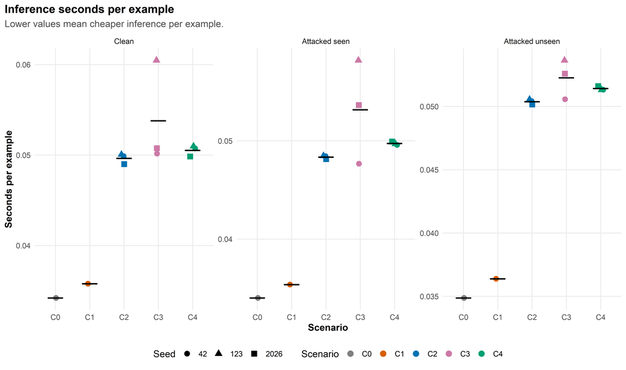

```r
p_seconds_per_example <- split_metadata |>
  ggplot(aes(x = scenario_short, y = seconds_per_example, color = scenario_short)) +
  geom_point(aes(shape = factor(seed)), size = 3.1, position = position_jitter(width = 0.08, height = 0)) +
  stat_summary(
    fun = mean,
    geom = "crossbar",
    width = 0.45,
    color = "black",
    linewidth = 0.35
  ) +
  facet_wrap(~ split_label, scales = "free_y") +
  scale_color_manual(values = scenario_palette, drop = FALSE) +
  labs(
    title = "Inference seconds per example",
    subtitle = "Lower values mean cheaper inference per example.",
    x = "Scenario",
    y = "Seconds per example",
    color = "Scenario",
    shape = "Seed"
  ) +
  base_theme()

print(p_seconds_per_example)
```

```r
save_inference_figure(
  p_seconds_per_example,
  "02_inference_seconds_per_example_by_split.png",
  width = 11,
  height = 6.5
)
```

## 14.3 Examples per second by split

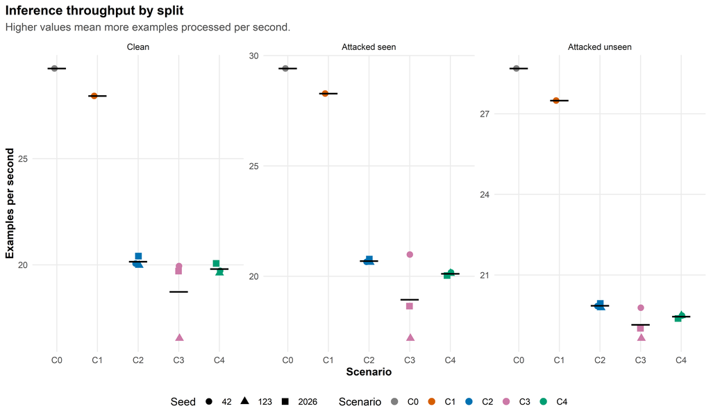

```r
p_examples_per_second <- split_metadata |>
  ggplot(aes(x = scenario_short, y = examples_per_second, color = scenario_short)) +
  geom_point(aes(shape = factor(seed)), size = 3.1, position = position_jitter(width = 0.08, height = 0)) +
  stat_summary(
    fun = mean,
    geom = "crossbar",
    width = 0.45,
    color = "black",
    linewidth = 0.35
  ) +
  facet_wrap(~ split_label, scales = "free_y") +
  scale_color_manual(values = scenario_palette, drop = FALSE) +
  labs(
    title = "Inference throughput by split",
    subtitle = "Higher values mean more examples processed per second.",
    x = "Scenario",
    y = "Examples per second",
    color = "Scenario",
    shape = "Seed"
  ) +
  base_theme()

print(p_examples_per_second)
```

```r
save_inference_figure(
  p_examples_per_second,
  "03_inference_examples_per_second_by_split.png",
  width = 11,
  height = 6.5
)
```

## 14.4 Relative overhead vs C0

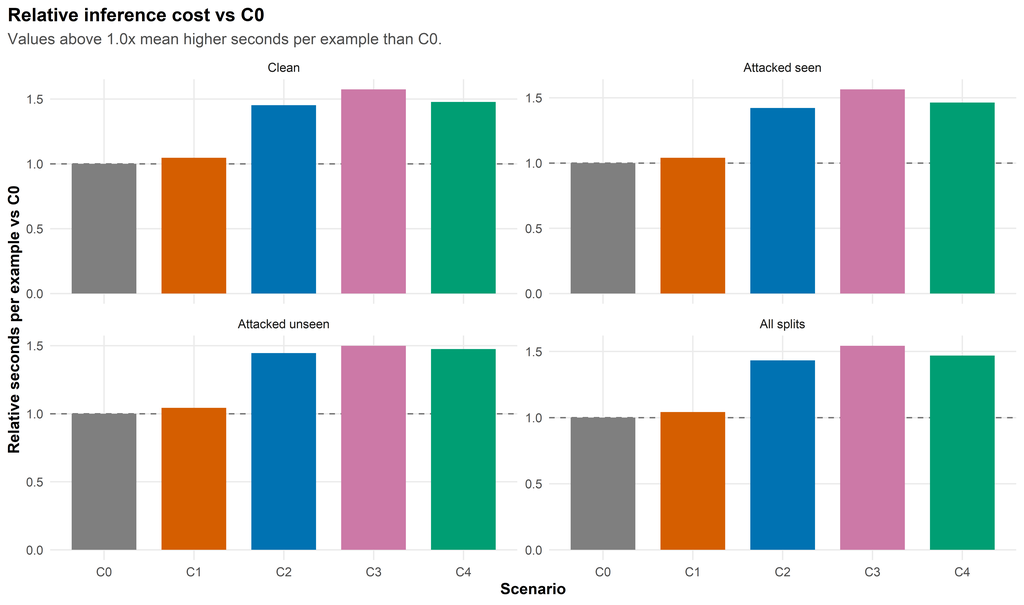

```r
p_relative_overhead <- overhead_vs_c0 |>
  filter(split %in% c("test_clean", "test_attacked_seen", "test_attacked_unseen", "all_splits")) |>
  ggplot(aes(x = scenario_short, y = relative_seconds_per_example_vs_c0, fill = scenario_short)) +
  geom_hline(yintercept = 1, linetype = "dashed", color = "grey45") +
  geom_col(width = 0.72, show.legend = FALSE) +
  facet_wrap(~ split_label, scales = "free_y") +
  scale_fill_manual(values = scenario_palette, drop = FALSE) +
  labs(
    title = "Relative inference cost vs C0",
    subtitle = "Values above 1.0x mean higher seconds per example than C0.",
    x = "Scenario",
    y = "Relative seconds per example vs C0"
  ) +
  base_theme()

print(p_relative_overhead)
```

```r
save_inference_figure(
  p_relative_overhead,
  "04_relative_inference_cost_vs_c0.png",
  width = 11,
  height = 6.5
)
```

## 14.5 Run-level total inference time

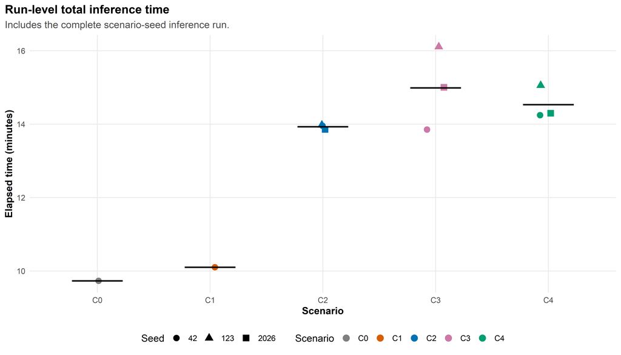

```r
p_run_total <- run_metadata |>
  ggplot(aes(x = scenario_short, y = elapsed_minutes, color = scenario_short)) +
  geom_point(aes(shape = factor(seed)), size = 3.4, position = position_jitter(width = 0.08, height = 0)) +
  stat_summary(
    fun = mean,
    geom = "crossbar",
    width = 0.45,
    color = "black",
    linewidth = 0.35
  ) +
  scale_color_manual(values = scenario_palette, drop = FALSE) +
  labs(
    title = "Run-level total inference time",
    subtitle = "Includes the complete scenario-seed inference run.",
    x = "Scenario",
    y = "Elapsed time (minutes)",
    color = "Scenario",
    shape = "Seed"
  ) +
  base_theme()

print(p_run_total)
```

```r
save_inference_figure(
  p_run_total,
  "05_run_level_total_inference_time.png",
  width = 10.5,
  height = 6
)
```

## 14.6 Run overhead

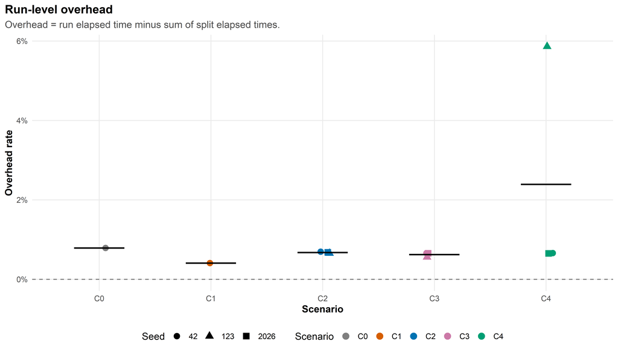

```r
p_run_overhead <- run_metadata |>
  ggplot(aes(x = scenario_short, y = run_overhead_rate, color = scenario_short)) +
  geom_hline(yintercept = 0, linetype = "dashed", color = "grey45") +
  geom_point(aes(shape = factor(seed)), size = 3.4, position = position_jitter(width = 0.08, height = 0)) +
  stat_summary(
    fun = mean,
    geom = "crossbar",
    width = 0.45,
    color = "black",
    linewidth = 0.35
  ) +
  scale_color_manual(values = scenario_palette, drop = FALSE) +
  scale_y_continuous(labels = scales::percent_format(accuracy = 1)) +
  labs(
    title = "Run-level overhead",
    subtitle = "Overhead = run elapsed time minus sum of split elapsed times.",
    x = "Scenario",
    y = "Overhead rate",
    color = "Scenario",
    shape = "Seed"
  ) +
  base_theme()

print(p_run_overhead)
```

```r
save_inference_figure(
  p_run_overhead,
  "06_run_level_inference_overhead.png",
  width = 10.5,
  height = 6
)
```

## 14.7 Normalized null rate

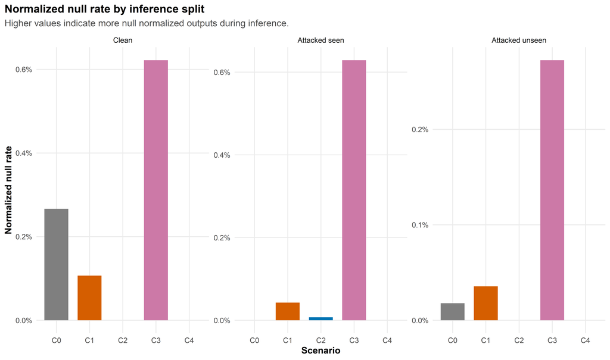

```r
p_null_rate <- split_summary_by_scenario |>
  ggplot(aes(x = scenario_short, y = normalized_null_rate, fill = scenario_short)) +
  geom_col(width = 0.72, show.legend = FALSE) +
  facet_wrap(~ split_label, scales = "free_y") +
  scale_fill_manual(values = scenario_palette, drop = FALSE) +
  scale_y_continuous(labels = scales::percent_format(accuracy = 0.1)) +
  labs(
    title = "Normalized null rate by inference split",
    subtitle = "Higher values indicate more null normalized outputs during inference.",
    x = "Scenario",
    y = "Normalized null rate"
  ) +
  base_theme()

print(p_null_rate)
```

```r
save_inference_figure(
  p_null_rate,
  "07_normalized_null_rate_by_split.png",
  width = 11,
  height = 6.5
)
```

## 14.8 Inference timeline

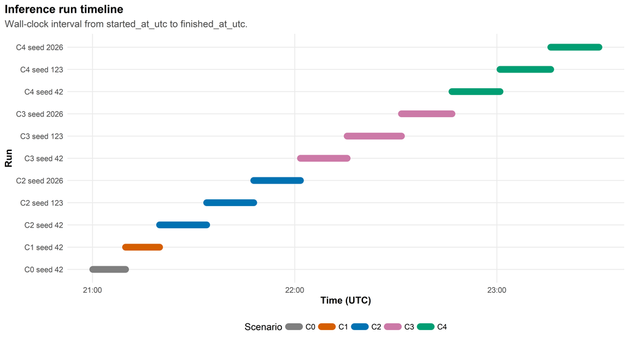

```r
timeline_data <- run_metadata |>
  mutate(
    run_label = paste0(scenario_short, " seed ", seed),
    run_label = fct_reorder(run_label, as.numeric(started_at))
  )

p_timeline <- timeline_data |>
  ggplot(aes(y = run_label, color = scenario_short)) +
  geom_segment(
    aes(x = started_at, xend = finished_at, yend = run_label),
    linewidth = 4,
    lineend = "round"
  ) +
  scale_color_manual(values = scenario_palette, drop = FALSE) +
  labs(
    title = "Inference run timeline",
    subtitle = "Wall-clock interval from started_at_utc to finished_at_utc.",
    x = "Time (UTC)",
    y = "Run",
    color = "Scenario"
  ) +
  base_theme()

print(p_timeline)
```

```r
save_inference_figure(
  p_timeline,
  "08_inference_run_timeline.png",
  width = 11,
  height = 6
)
```

## 14.9 Split timeline

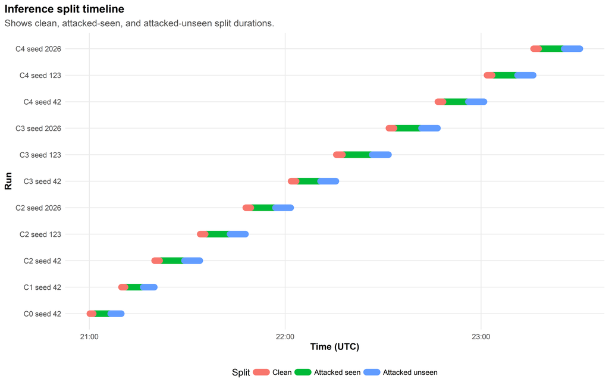

```r
split_timeline_data <- split_metadata |>
  mutate(
    run_label = paste0(scenario_short, " seed ", seed),
    run_label = fct_reorder(run_label, as.numeric(started_at))
  )

p_split_timeline <- split_timeline_data |>
  ggplot(aes(y = run_label, color = split_label)) +
  geom_segment(
    aes(x = started_at, xend = finished_at, yend = run_label),
    linewidth = 4,
    lineend = "round"
  ) +
  labs(
    title = "Inference split timeline",
    subtitle = "Shows clean, attacked-seen, and attacked-unseen split durations.",
    x = "Time (UTC)",
    y = "Run",
    color = "Split"
  ) +
  base_theme()

print(p_split_timeline)
```

```r
save_inference_figure(
  p_split_timeline,
  "09_inference_split_timeline.png",
  width = 11,
  height = 7
)
```

## 14.10 Cost-quality figures

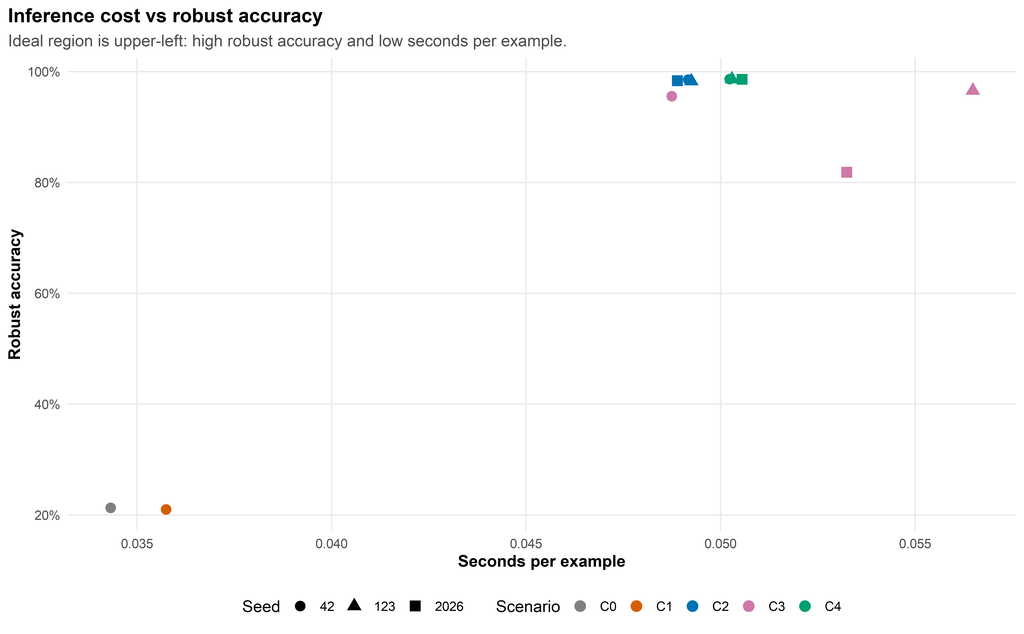

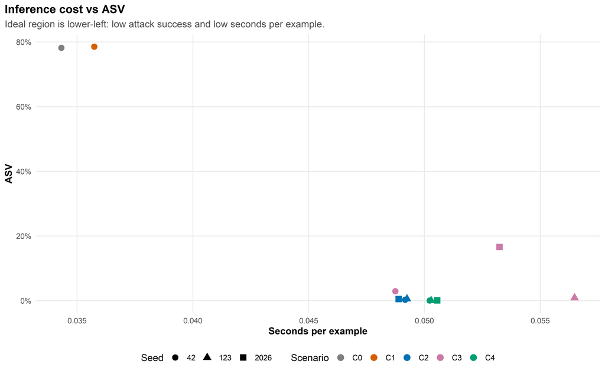

```r
if (!is.null(inference_cost_quality)) {
  cost_quality_all_attacks <- inference_cost_quality |>
    filter(split == "all_attacks")

  p_cost_quality <- cost_quality_all_attacks |>
    ggplot(aes(x = seconds_per_example, y = accuracy, color = scenario_short)) +
    geom_point(aes(shape = factor(seed)), size = 3.4) +
    scale_color_manual(values = scenario_palette, drop = FALSE) +
    scale_y_continuous(labels = scales::percent_format(accuracy = 1)) +
    labs(
      title = "Inference cost vs robust accuracy",
      subtitle = "Ideal region is upper-left: high robust accuracy and low seconds per example.",
      x = "Seconds per example",
      y = "Robust accuracy",
      color = "Scenario",
      shape = "Seed"
    ) +
    base_theme()

  print(p_cost_quality)

  save_inference_figure(
    p_cost_quality,
    "10_inference_cost_vs_robust_accuracy.png",
    width = 10.5,
    height = 6.5
  )

  p_cost_asv <- cost_quality_all_attacks |>
    ggplot(aes(x = seconds_per_example, y = asv_rate, color = scenario_short)) +
    geom_point(aes(shape = factor(seed)), size = 3.4) +
    scale_color_manual(values = scenario_palette, drop = FALSE) +
    scale_y_continuous(labels = scales::percent_format(accuracy = 1)) +
    labs(
      title = "Inference cost vs ASV",
      subtitle = "Ideal region is lower-left: low attack success and low seconds per example.",
      x = "Seconds per example",
      y = "ASV",
      color = "Scenario",
      shape = "Seed"
    ) +
    base_theme()

  print(p_cost_asv)

  save_inference_figure(
    p_cost_asv,
    "11_inference_cost_vs_asv.png",
    width = 10.5,
    height = 6.5
  )
}
```

# 15 Paper-ready inference cost table

```r
paper_inference_cost_table <- scenario_inference_summary |>
  filter(split %in% c("test_clean", "all_attacks", "all_splits")) |>
  select(
    scenario_short,
    split_label,
    prompt_strategy,
    n_runs,
    seeds,
    mean_rows,
    mean_elapsed_minutes,
    mean_seconds_per_example,
    mean_examples_per_second,
    normalized_null_rate,
    total_elapsed_hours,
    total_duration_label
  ) |>
  mutate(
    mean_rows = fmt_number(mean_rows, accuracy = 1),
    mean_elapsed_minutes = fmt_number(mean_elapsed_minutes),
    mean_seconds_per_example = fmt_number(mean_seconds_per_example, accuracy = 0.0001),
    mean_examples_per_second = fmt_number(mean_examples_per_second, accuracy = 0.001),
    normalized_null_rate = fmt_pct(normalized_null_rate),
    total_elapsed_hours = fmt_number(total_elapsed_hours)
  )

write_inference_csv(paper_inference_cost_table, "16_paper_ready_inference_cost_table.csv")

paper_inference_cost_table |>
  knitr::kable(
    caption = "Table 12 - Paper-ready inference cost table."
  )
```

Table 12 - Paper-ready inference cost table.

| scenario_short | split_label | prompt_strategy | n_runs | seeds | mean_rows | mean_elapsed_minutes | mean_seconds_per_example | mean_examples_per_second | normalized_null_rate | total_elapsed_hours | total_duration_label |
| --- | --- | --- | --- | --- | --- | --- | --- | --- | --- | --- | --- |
| C0 | Clean | plain | 1 | 42 | 1,876 | 1.07 | 0.0342 | 29.244 | 0.3% | 0.02 | 0h 1m 4s |
| C0 | All attacks | plain | 1 | 42 | 15,008 | 8.59 | 0.0343 | 29.135 | 0.0% | 0.14 | 0h 8m 35s |
| C0 | All splits | plain | 1 | 42 | 16,884 | 9.65 | 0.0343 | 29.147 | 0.0% | 0.16 | 0h 9m 39s |
| C1 | Clean | struq | 1 | 42 | 1,876 | 1.12 | 0.0358 | 27.953 | 0.1% | 0.02 | 0h 1m 7s |
| C1 | All attacks | struq | 1 | 42 | 15,008 | 8.94 | 0.0357 | 27.975 | 0.0% | 0.15 | 0h 8m 56s |
| C1 | All splits | struq | 1 | 42 | 16,884 | 10.06 | 0.0357 | 27.973 | 0.0% | 0.17 | 0h 10m 4s |
| C2 | Clean | struq | 3 | 42, 123, 2026 | 1,876 | 1.55 | 0.0496 | 20.146 | 0.0% | 0.08 | 0h 4m 39s |
| C2 | All attacks | struq | 3 | 42, 123, 2026 | 15,008 | 12.28 | 0.0491 | 20.366 | 0.0% | 0.61 | 0h 36m 51s |
| C2 | All splits | struq | 3 | 42, 123, 2026 | 16,884 | 13.83 | 0.0492 | 20.341 | 0.0% | 0.69 | 0h 41m 30s |
| C3 | Clean | secalign | 3 | 42, 123, 2026 | 1,876 | 1.68 | 0.0538 | 18.726 | 0.6% | 0.08 | 0h 5m 3s |
| C3 | All attacks | secalign | 3 | 42, 123, 2026 | 15,008 | 13.21 | 0.0528 | 19.000 | 0.5% | 0.66 | 0h 39m 38s |
| C3 | All splits | secalign | 3 | 42, 123, 2026 | 16,884 | 14.90 | 0.0529 | 18.965 | 0.5% | 0.74 | 0h 44m 41s |
| C4 | Clean | instruction_hierarchy | 3 | 42, 123, 2026 | 1,876 | 1.58 | 0.0505 | 19.798 | 0.0% | 0.08 | 0h 4m 44s |
| C4 | All attacks | instruction_hierarchy | 3 | 42, 123, 2026 | 15,008 | 12.60 | 0.0504 | 19.858 | 0.0% | 0.63 | 0h 37m 47s |
| C4 | All splits | instruction_hierarchy | 3 | 42, 123, 2026 | 16,884 | 14.18 | 0.0504 | 19.851 | 0.0% | 0.71 | 0h 42m 32s |

# 16 Methodological notes

```r
cat("
## How to interpret this report

Elapsed time is the wall-clock time reported by the inference metadata. Seconds per example is the main normalized inference-cost metric because the splits have different numbers of rows.

Examples per second is the reciprocal throughput view. Higher examples per second means faster inference.

Relative overhead vs C0 compares mean seconds per example for each scenario and split against the C0 base-model reference. Values above 1.0x indicate more expensive inference than C0.

C1 is useful for estimating the cost of the StruQ formatting strategy without adapter training. C2, C3, and C4 include trained adapter-based scenarios.

The quality-cost section is optional. It appears only when tables/descriptive/01_inference_compact.csv is available.
")
```

## 16.1 How to interpret this report

Elapsed time is the wall-clock time reported by the inference metadata. Seconds per example is the main normalized inference-cost metric because the splits have different numbers of rows.

Examples per second is the reciprocal throughput view. Higher examples per second means faster inference.

Relative overhead vs C0 compares mean seconds per example for each scenario and split against the C0 base-model reference. Values above 1.0x indicate more expensive inference than C0.

C1 is useful for estimating the cost of the StruQ formatting strategy without adapter training. C2, C3, and C4 include trained adapter-based scenarios.

The quality-cost section is optional. It appears only when tables/descriptive/01_inference_compact.csv is available.

# 17 Generated files

Tables are saved in:

```
tables/inference_time_analysis/
```

Figures are saved in:

```
figures/inference_time_analysis/
```

Main files:

```
01_inference_experiment_metadata.csv
02_inference_result_files_from_summary.csv
03_inference_split_metadata_enriched.csv
04_inference_run_metadata_enriched.csv
05_split_summary_by_scenario.csv
06_aggregate_split_metadata.csv
07_scenario_inference_summary.csv
08_inference_overhead_vs_c0.csv
09_prompt_strategy_inference_summary.csv
10_inference_events_enriched.csv
11_inference_event_counts.csv
12_split_completion_events.csv
13_inference_error_files.csv
14_quality_metrics_by_split.csv
15_inference_cost_quality_joined.csv
16_paper_ready_inference_cost_table.csv

01_inference_elapsed_time_by_split.png
02_inference_seconds_per_example_by_split.png
03_inference_examples_per_second_by_split.png
04_relative_inference_cost_vs_c0.png
05_run_level_total_inference_time.png
06_run_level_inference_overhead.png
07_normalized_null_rate_by_split.png
08_inference_run_timeline.png
09_inference_split_timeline.png
10_inference_cost_vs_robust_accuracy.png
11_inference_cost_vs_asv.png
```